# CE083 - Estatística Computacional I

GABARITO

8 de dezembro, 2016

# Terceira prova

## Introdução

A revista [Forbes](http://www.forbes.com) cria anualmente uma lista com as maiores empresas do mundo, de acordo com valores de vendas, lucros e valor de mercado. Em 2004, esta lista correspondeu a 2000 empresas de todo o mundo e de diversas categorias.

## Dados

Os dados da lista das 2000 maiores empresas de 2004 estão no arquivo. As colunas são:

- `rank`: a posição geral da empresa no ranking
- `nome`: nome da empresa
- `pais`: país sede da empresa
- `categoria`: a área de atuação (ramo) da empresa
- `vendas`: volume de vendas, em bilhões de dólares
- `lucros`: lucro da empresa, em bilhões de dólares
- `valor.mercado`: valor de mercado da empresa, em bilhões de dólares

Com isso:

- Faça a importação dos dados, e verifique sua estrutura.

```r
dados <- read.table("dados_Forbes2000.csv", header = TRUE,
                    sep = ",", dec = ".")
str(dados)
```

```
## 'data.frame':    2000 obs. of  7 variables:
##  $ rank         : int  1 2 3 4 5 6 7 8 9 10 ...
##  $ nome         : Factor w/ 2000 levels "Aareal Bank",..: 438 747 100 659 311 219 870 1827 663 1921 ...
##  $ pais         : Factor w/ 61 levels "Africa","Australia",..: 60 60 60 60 56 60 56 28 60 60 ...
##  $ categoria    : Factor w/ 27 levels "Aeroespacial e defesa",..: 3 6 19 15 15 3 3 5 18 27 ...
##  $ vendas       : num  94.7 134.2 76.7 222.9 232.6 ...
##  $ lucros       : num  17.85 15.59 6.46 20.96 10.27 ...
##  $ valor.mercado: num  255 329 195 277 174 ...
```

```r
summary(dados)
```

```
##       rank                              nome                  pais
##  Min.   :   1.0   Aareal Bank             :   1   United States :751
##  1st Qu.: 500.8   ABB Group               :   1   Japan         :316
##  Median :1000.5   Abbey National          :   1   United Kingdom:137
##  Mean   :1000.5   Abbott Laboratories     :   1   Germany       : 65
##  3rd Qu.:1500.2   Abercrombie & Fitch     :   1   France        : 63
##  Max.   :2000.0   Abertis Infraestructuras:   1   Canada        : 56
##                   (Other)                 :1994   (Other)       :612
##                    categoria        vendas            lucros
##  Bancário               : 313   Min.   :  0.010   Min.   :-25.8300
##  Recursos diversificados: 158   1st Qu.:  2.018   1st Qu.:  0.0800
##  Seguro                 : 112   Median :  4.365   Median :  0.2000
##  Utilidades             : 110   Mean   :  9.697   Mean   :  0.3811
##  Materiais              :  97   3rd Qu.:  9.547   3rd Qu.:  0.4400
##  Óleo e gás             :  90   Max.   :256.330   Max.   : 20.9600
##  (Other)                :1120                     NA's   :5
##  valor.mercado
##  Min.   :  0.02
##  1st Qu.:  2.72
##  Median :  5.15
##  Mean   : 11.88
##  3rd Qu.: 10.60
##  Max.   :328.54
##
```

## Análise exploratória

- Faça um sumário estatístico dos dados.

```r
summary(dados)
```

```
##       rank                              nome                  pais
##  Min.   :   1.0   Aareal Bank             :   1   United States :751
##  1st Qu.: 500.8   ABB Group               :   1   Japan         :316
##  Median :1000.5   Abbey National          :   1   United Kingdom:137
##  Mean   :1000.5   Abbott Laboratories     :   1   Germany       : 65
##  3rd Qu.:1500.2   Abercrombie & Fitch     :   1   France        : 63
##  Max.   :2000.0   Abertis Infraestructuras:   1   Canada        : 56
##                   (Other)                 :1994   (Other)       :612
##                    categoria        vendas            lucros
##  Bancário               : 313   Min.   :  0.010   Min.   :-25.8300
##  Recursos diversificados: 158   1st Qu.:  2.018   1st Qu.:  0.0800
##  Seguro                 : 112   Median :  4.365   Median :  0.2000
##  Utilidades             : 110   Mean   :  9.697   Mean   :  0.3811
##  Materiais              :  97   3rd Qu.:  9.547   3rd Qu.:  0.4400
##  Óleo e gás             :  90   Max.   :256.330   Max.   : 20.9600
##  (Other)                :1120                     NA's   :5
##  valor.mercado
##  Min.   :  0.02
##  1st Qu.:  2.72
##  Median :  5.15
##  Mean   : 11.88
##  3rd Qu.: 10.60
##  Max.   :328.54
##
```

- Verifique quantos países e quantas categorias diferentes estão na tabela.

```r
length(unique(dados$pais))
```

```
## [1] 61
```

```r
length(unique(dados$categoria))
```

```
## [1] 27
```

- Faça uma tabela de frequência absoluta para as categorias, e ordene essa tabela em ordem decrescente, ou seja, da categoria com o maior número de empresas para a menor. (Dica: veja a função `sort()`).

```r
tab.cat <- sort(table(dados$categoria), decreasing = TRUE)
tab.cat
```

```
##
##                          Bancário           Recursos diversificados
##                               313                               158
##                            Seguro                        Utilidades
##                               112                               110
##                         Materiais                        Óleo e gás
##                                97                                90
##                            Varejo       Alimentos, bebidas e tabaco
##                                88                                83
##                       Transportes                        Construção
##                                80                                79
##                     Bens duráveis Serviços e material para empresas
##                                74                                70
##       Serviços de telecomunicação  Equipamentos e serviços de saúde
##                                67                                65
##                             Mídia         Tecnologia e equipamentos
##                                61                                59
##                   Bens de capital                          Químicos
##                                53                                50
##            Drogas e biotecnologia    Produtos domésticos e pessoais
##                                45                                44
##      Hotéis, restaurantes e lazer             Mercados de alimentos
##                                37                                33
##                     Conglomerados               Software e serviços
##                                31                                31
##                    Semicondutores               Empresas comerciais
##                                26                                25
##             Aeroespacial e defesa
##                                19
```

- De acordo com essa ordenação, mostre quais são as 5 maiores categorias (em frequência de ocorrência).

```r
head(tab.cat, 5)
## OU
# tab.cat[1:5]
```

```
##
##                Bancário Recursos diversificados                  Seguro
##                     313                     158                     112
##              Utilidades               Materiais
##                     110                      97
```

- Faça o mesmo para os países: crie uma tabela de frequência absoluta ordenada em ordem crescente e depois identifique os 5 países com maior número de empresas da lista.

```r
tab.pais <- sort(table(dados$pais), decreasing = FALSE)
tab.pais
```

```
##
##                      Bahamas       France/ United Kingdom
##                            1                            1
##                      Islands                       Jordan
##                            1                            1
##                      Liberia                  New Zealand
##                            1                            1
##                     Pakistan       Panama/ United Kingdom
##                            1                            1
##                         Peru                       Poland
##                            1                            1
##    United Kingdom/ Australia  United Kingdom/ Netherlands
##                            1                            1
## United Kingdom/ South Africa                    Venezuela
##                            1                            1
##                       Africa    Australia/ United Kingdom
##                            2                            2
##               Czech Republic                      Hungary
##                            2                            2
##                   Luxembourg  Netherlands/ United Kingdom
##                            2                            2
##                  Philippines                        Chile
##                            2                            4
##                   Kong/China                        Korea
##                            4                            4
##               Cayman Islands                    Indonesia
##                            5                            7
##                     Portugal                      Austria
##                            7                            8
##                      Ireland                       Israel
##                            8                            8
##                       Norway                      Belgium
##                            8                            9
##                     Thailand                      Denmark
##                            9                           10
##                      Finland                       Greece
##                           11                           12
##                       Russia                       Turkey
##                           12                           12
##                       Brazil                 South Africa
```

[output cut: 8 more lines]

```
##                           26                           27
##                  Netherlands                        Spain
##                           28                           29
##                  Switzerland                       Taiwan
##                           34                           35
##                    Australia                        Italy
##                           37                           41
##                  South Korea                       Canada
##                           45                           56
##                       France                      Germany
##                           63                           65
##               United Kingdom                        Japan
##                          137                          316
##                United States
##                          751
```

```r
tail(tab.pais, 5)
```

```
##
##         France        Germany United Kingdom          Japan  United States
##             63             65            137            316            751
```

- Identifique quais são as empresas brasileiras presentes nessa lista.

```r
dados$nome[dados$pais == "Brazil"]
```

```
##  [1] Petrobras-Petrsleo Brasil Banco Bradesco Group
##  [3] Banco do Brasil           Itazsa
##  [5] Eletrobras                Vale do Rio Doce
##  [7] Unibanco Group            AmBev
##  [9] Metalurgica Gerdau        Embraer
## [11] Tele Norte Leste          Aracruz Celulose
## [13] CBD-Brasil Distribuieco   Brasil Telecom
## [15] CSN-Cia Siderurgica
## 2000 Levels: Aareal Bank ABB Group Abbey National ... Zurich Financial Services
```

- Identifique o nome das empresas que possuem os maiores valores de: vendas, lucros e valor de mercado, respectivamente.

```r
dados$nome[which.max(dados$vendas)]
```

```
## [1] Wal-Mart Stores
## 2000 Levels: Aareal Bank ABB Group Abbey National ... Zurich Financial Services
```

```r
dados$nome[which.max(dados$lucros)]
```

```
## [1] ExxonMobil
## 2000 Levels: Aareal Bank ABB Group Abbey National ... Zurich Financial Services
```

```r
dados$nome[which.max(dados$valor.mercado)]
```

```
## [1] General Electric
## 2000 Levels: Aareal Bank ABB Group Abbey National ... Zurich Financial Services
```

- Crie uma tabela que ordene (em ordem decrescente) as empresas de acordo com as vendas (mantendo todas as outras colunas da tabela). Mostre as 5 primeiras linhas dessa tabela, ou seja, as 5 maiores empresas de acordo com as vendas. (Dica: veja a função `order()`).

```r
head(dados[order(dados$vendas, decreasing = TRUE), ], 5)
```

```
##    rank            nome           pais     categoria vendas lucros
## 10   10 Wal-Mart Stores  United States        Varejo 256.33   9.05
## 5     5              BP United Kingdom    Óleo e gás 232.57  10.27
## 4     4      ExxonMobil  United States    Óleo e gás 222.88  20.96
## 29   29  General Motors  United States Bens duráveis 185.52   3.82
## 75   75      Ford Motor  United States Bens duráveis 164.20   0.76
##    valor.mercado
## 10        243.74
## 5         173.54
## 4         277.02
## 29         27.47
## 75         26.29
```

- Faça um histograma dos lucros de todas as empresas.

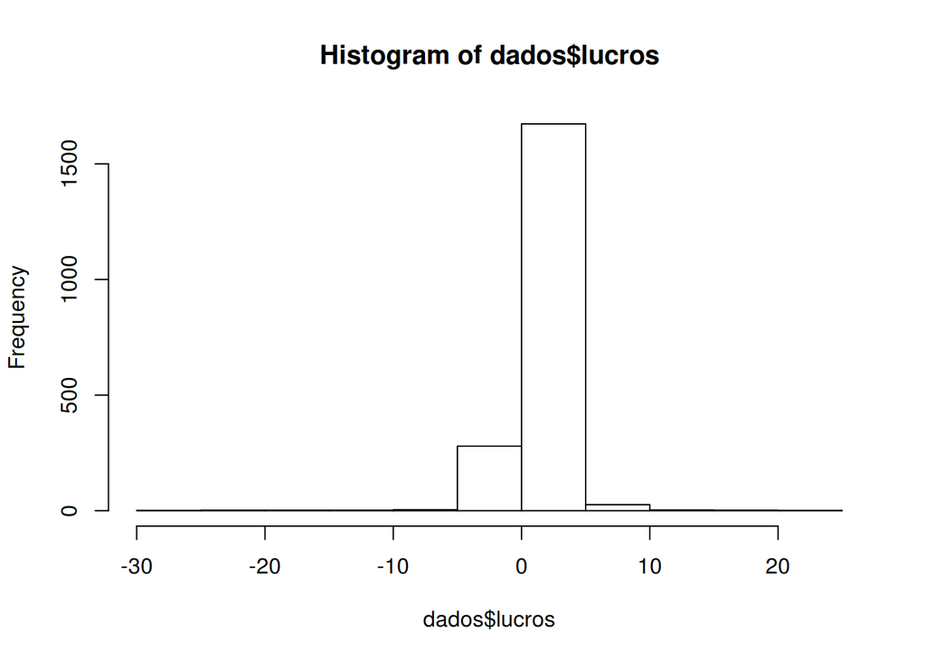

```r
hist(dados$lucros)
```

- Calcule a mediana dos lucros para cada categoria, e mostre quais são as 5 categorias que apresentaram maiores lucros.

```r
tab.lucro <- with(dados, tapply(lucros, categoria,
                                median, na.rm = TRUE))
head(sort(tab.lucro, decreasing = TRUE), 5)
## OU
# sort(tab.lucro, decreasing = TRUE)[1:5]
```

```
##         Drogas e biotecnologia                     Óleo e gás
##                          0.350                          0.350
## Produtos domésticos e pessoais    Serviços de telecomunicação
##                          0.310                          0.275
##    Alimentos, bebidas e tabaco
##                          0.270
```

- Faça um histograma do valor de mercado e das vendas (na mesma janela gráfica, lado a lado).

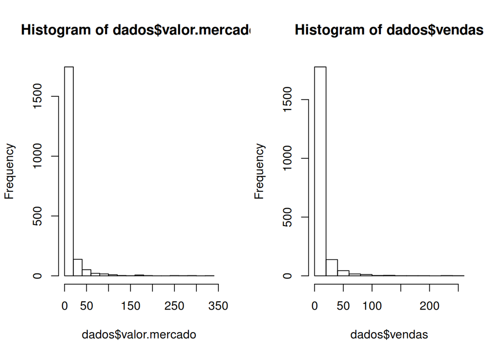

```r
par(mfrow = c(1,2))
hist(dados$valor.mercado)
hist(dados$vendas)
par(mfrow = c(1,1))
```

- Crie duas novas colunas no seu objeto de dados: `log.valor.mercado` e `log.vendas`, com o logaritmo do valor de mercado e das vendas, respectivamente. Faça novamente os histogramas com estas duas novas variáveis.

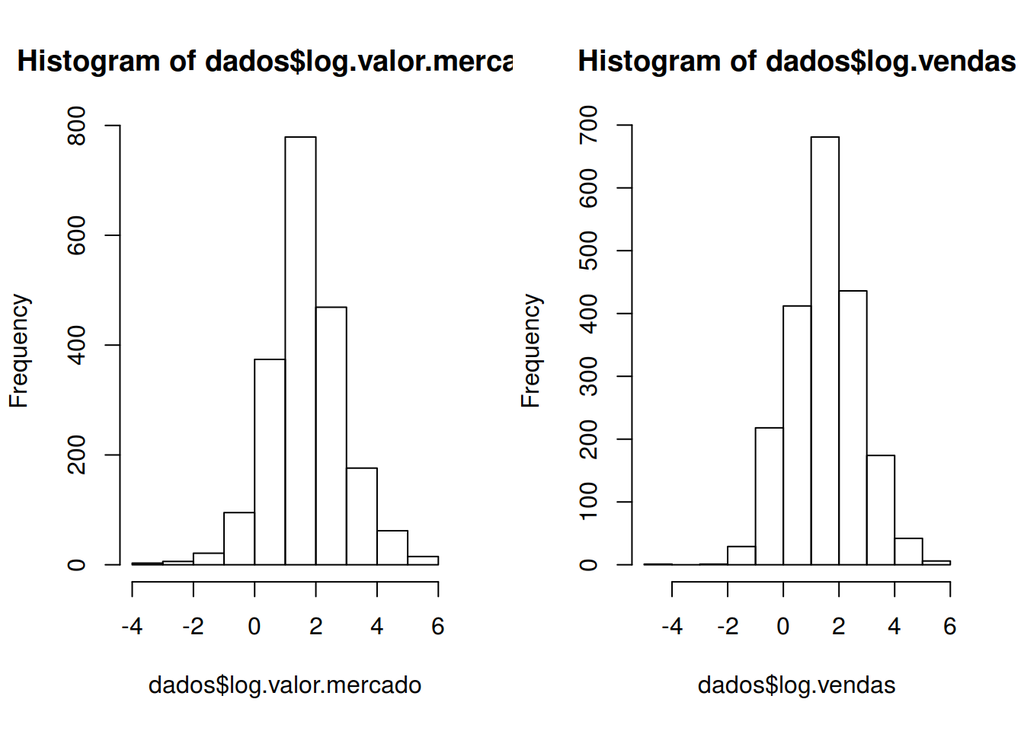

```r
dados$log.valor.mercado <- log(dados$valor.mercado)
dados$log.vendas <- log(dados$vendas)
par(mfrow = c(1,2))
hist(dados$log.valor.mercado)
hist(dados$log.vendas)
par(mfrow = c(1,1))
```

- O valor de mercado de uma empresa depende do valor das vendas, ou seja, quanto maiores forem as vendas, maior será o valor de mercado. Faça um gráfico de dispersão entre o logaritmo do valor de mercado e o logaritmo do valor de vendas para analisar esta afirmação.

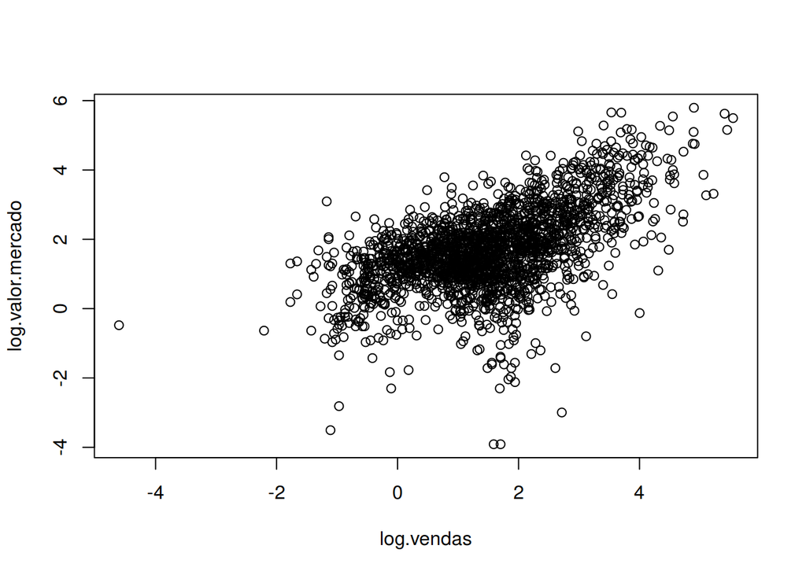

```r
plot(log.valor.mercado ~ log.vendas, data = dados)
```

## Inferência sobre a média de lucros

De acordo com o histograma dos lucros (acima), nota-se que existe uma grande variação ao redor do zero (ou seja, algumas empresas tiveram lucro positivo, enquanto que outras tiveram prejuízo). Para verificar isso, será construído um intervalo de confiança e um teste de hipótese.

Sabemos que o intervalo de confiança para média de uma distribuição normal com variância desconhecida, para uma amostra de tamanho $n$ é dado por:

$$\left(\bar{x} - t_t \sqrt{\frac{s^2}{n}} \quad, \quad
\bar{x} + t_t \sqrt{\frac{s^2}{n}} \right)$$

onde $t_t$ é o quantil de ordem $1-\alpha/2$ da distribuição $t$ de Student, com $n-1$ graus de liberdade.

Considerando que estamos interessados em obter um intervalo de confiança para a média dos lucros, faça o que se pede:

- Calcule o tamanho da amostra, a média e a variância amostral dos lucros.

```r
n <- length(dados$lucros)
n
```

```
## [1] 2000
```

```r
t.m <- mean(dados$lucros, na.rm = TRUE)
t.m
```

```
## [1] 0.3811328
```

```r
t.v <- var(dados$lucros, na.rm = TRUE)
t.v
```

```
## [1] 3.116828
```

- Monte o intervalo de confiança utilizando os quantis da distribuição $t$, para obter um IC de 95% de confiança.

```r
t.ic <- t.m + qt(c(0.025, 0.975), df = n - 1) * sqrt(t.v/n)
t.ic
```

```
## [1] 0.3037129 0.4585527
```

Além do intervalo de confiança, podemos realizar um teste de hipótese para testar se a média dos lucros é igual a determinado valor. Os procedimentos gerais para este teste de hipótese são:

1. Definir a hipótese nula ($H_0$) e a alternativa ($H_1$)
2. Definir um nível de **significância** $\alpha$ (ex.: $\alpha = 0,05$), que irá determinar o nível de **confiança** $100(1-\alpha)\%$ do teste
3. Determinar a **região de rejeição** com base no nível de significância $\rightarrow$ valor crítico
4. Calcular a **estatística de teste**, sob a hipótese nula
   $$t_{calc} = \frac{\bar{x} - \mu_0}{s/\sqrt{n}}$$
5. Rejeitar a hipótese nula se a estatística de teste calculada estiver dentro da região de rejeição ($|t_{calc}| > |t_{crit}|$)

Portanto, se desejamos testar a hipótese de que o lucro médio das empresas é zero, temos as seguintes hipóteses:

$$\begin{align}
\text{H}_0: \mu = 0 \\
\text{H}_1: \mu \neq 0 \\
\end{align}$$

Usando um nível de significância $\alpha = 0,05$, realize este teste de hipótese usando a função `t.test()`.

```r
t.test(dados$lucros)
```

```
##
##  One Sample t-test
##
## data:  dados$lucros
## t = 9.6425, df = 1994, p-value < 2.2e-16
## alternative hypothesis: true mean is not equal to 0
## 95 percent confidence interval:
##  0.3036159 0.4586498
## sample estimates:
## mean of x
## 0.3811328
```

Qual a sua conclusão a respeito do teste de hipótese?

**Resposta**: *como o p-valor do teste de hipótese foi menor do que o nível de significância (0,05), então rejeitamos a hipótese nula, ou seja, existem evidências que a média dos lucros destas empresas é diferente de zero.*

## Ajustando um modelo linear

Para avaliar a relação entre vendas e valor de mercado, podemos ajustar um modelo de regressão linear simples, que irá indicar se esta relação é significativa.

Um **modelo linear** entre duas variáveis $X$ e $Y$, é definido matematicamente como uma equação com dois parâmetros desconhecidos,

$$Y = \beta_0 + \beta_1 X$$

Onde $\beta_0$ é o intercepto do modelo (valor de $Y$ quando $X=0$), e $\beta_1$ é o coeficiente angular ou inclinação da reta.

Assim, dados $n$ pares de valores, $(X_1, Y_1), (X_2, Y_2), \ldots, (X_n, Y_n)$, se for admitido que $Y$ é função linear de $X$, pode-se estabelecer uma regressão linear simples, cujo modelo estatístico é

$$Y_i = \beta_0 + \beta_1 X_i + e_i, \quad i = 1, 2, \ldots, n$$

Como através de uma amostra obtemos uma estimativa da verdadeira equação de regressão, denominamos

$$\hat{Y}_i = \hat{\beta}_0 + \hat{\beta}_1 X_i$$

ou seja, $\hat{Y}_i$ é o valor **estimado** de $Y_i$, através das **estimativas** de $\beta_0$ e $\beta_1$, que chamaremos de $\hat{\beta}_0$ e $\hat{\beta}_1$. Para cada valor de $Y_i$, temos um valor $\hat{Y}_i$ estimado pela equação de regressão,

$$Y_i = \hat{Y}_i + e_i$$

Portanto, o erro (ou desvio) de cada observação em relação ao modelo adotado será

$$\begin{align}
e_i &= Y_i - \hat{Y}_i \\
e_i &= Y_i - (\beta_0 + \beta_1 X_i)
\end{align}$$

Comumente se assume que os erros possuem uma distribuição normal com média zero e variância constante, ou seja, $e_i \sim \text{N}(0, \sigma^2)$.

Através da **solução de mínimos quadrados**, obtemos as expressões para estimar os parâmetros $\beta_0$ e $\beta_1$:

$$\begin{align}
\hat{\beta}_1 &= \frac{\sum_{i=1}^{n}
(Y_i - \bar{Y})(X_i - \bar{X})}{
\sum_{i=1}^{n} (X_i - \bar{X})^2} \\
& \\
\hat{\beta_0} &= \bar{Y} - \hat{\beta}_1 \bar{X}
\end{align}$$

onde $\bar{X}$ e $\bar{Y}$ são as médias amostrais de $X$ e $Y$, respectivamente.

Como vimos pelas soluções acima, primeiro calculamos $\hat{\beta_1}$, e depois $\hat{\beta_0}$. Para facilitar as contas, vamos criar objetos `X` e `Y` com as colunas `log.vendas` e `log.valor.mercado` (saber quem é `X` e quem é `Y` faz parte da interpretação do problema), e `n` que é o tamanho da amostra.

```r
X <- dados$log.vendas
Y <- dados$log.valor.mercado
n <- length(X)
```

Agora calculamos $\hat{\beta_1}$ com

```r
## Crie um objeto chamado beta1
beta1 <- sum((Y - mean(Y))*(X - mean(X)))/sum((X - mean(X))^2)
beta1
```

```
## [1] 0.5450448
```

E $\hat{\beta_0}$ é calculado com

```r
## Crie um objeto chamado beta0
beta0 <- mean(Y) - beta1 * mean(X)
beta0
```

```
## [1] 0.8779514
```

Para conferir os seus cálculos e prosseguir com a análise, ajuste um modelo linear entre as duas variáveis consideradas, usando a função `lm()`, e verifique se os coeficientes estimados pela função são os mesmos que você calculou à mão.

```r
## Crie um objeto chamado mod com o modelo ajustado
mod <- lm(Y ~ X, data = dados)
mod
```

```
##
## Call:
## lm(formula = Y ~ X, data = dados)
##
## Coefficients:
## (Intercept)            X
##       0.878        0.545
```

Para avaliar a significância do modelo, podemos realizar uma **Análise de Variância** (ANOVA) para a regressão. Como vimos na estimação dos parâmetros, o objetivo é encontrar parâmetros que façam com que a soma de quadrados dos resíduos seja mínima. Podemos particionar a soma de quadrados da seguinte forma:

$$SQTot = SQMod + SQRes$$

Portanto, se um modelo é bem ajustado, esperamos que a soma de quadrados do modelo $SQMod$ seja grande, e a $SQRes$ sejá mínima. Um quadro de ANOVA para o modelo irá testar, através de um teste F, se a soma de quadrados do modelo é significativamente diferente de zero. Para fazer essa ANOVA, usamos a função `anova()`

```r
## Quadro de Análise de Variância
anova(mod)
```

```
## Analysis of Variance Table
##
## Response: Y
##             Df  Sum Sq Mean Sq F value    Pr(>F)
## X            1  899.01  899.01  920.92 < 2.2e-16 ***
## Residuals 1998 1950.46    0.98
## ---
## Signif. codes:  0 '***' 0.001 '**' 0.01 '*' 0.05 '.' 0.1 ' ' 1
```

Uma parte importante em uma análise de regressão linear é a verificação dos resíduos do modelo, ou seja, os desvios de cada valor observado $Y$ em relação aos valores **preditos** pelo modelo, $\hat{Y}$.

Como vimos que a suposição do modelo é de que os resíduos possuam uma distribuição normal com média 0 e variância constante, $e_i \sim \text{N}(0, \sigma^2)$, então podemos verificar essa suposição fazendo um histograma destes resíduos. Para isso, podemos extrair os resíduos diretamente do objeto `mod` com a função `residuals()`, e fazer o histograma destes resíduos

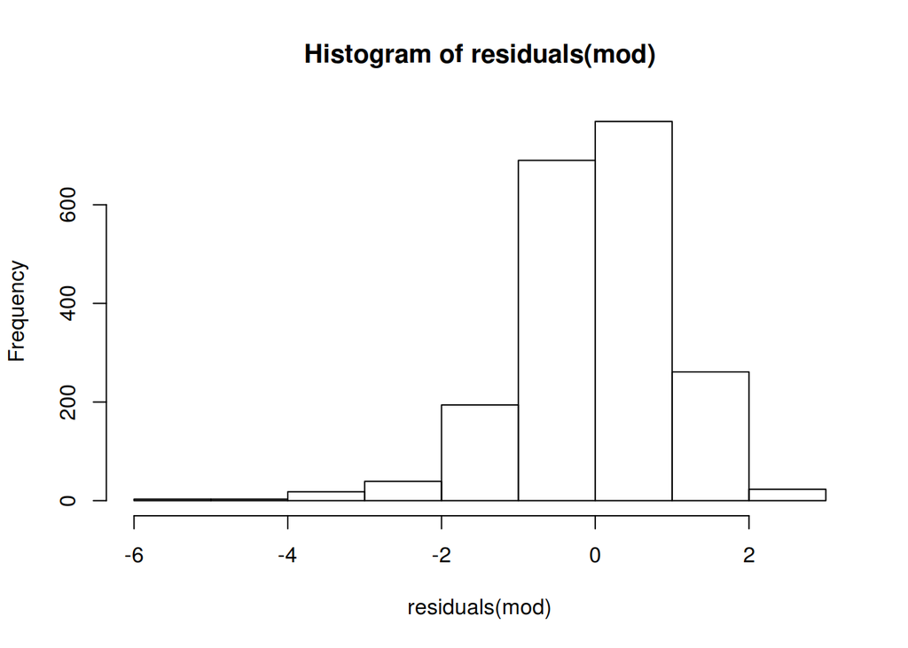

```r
## Faça um histograma dos resíduos do modelo
hist(residuals(mod))
```

Ainda com o objeto `mod`, podemos ajustar o modelo graficamente ao gráfico da relação entre `log.vendas` e `log.valor.mercado`. Para isso, usamos a função `abline()`, utilizada para inserir linhas em gráficos.

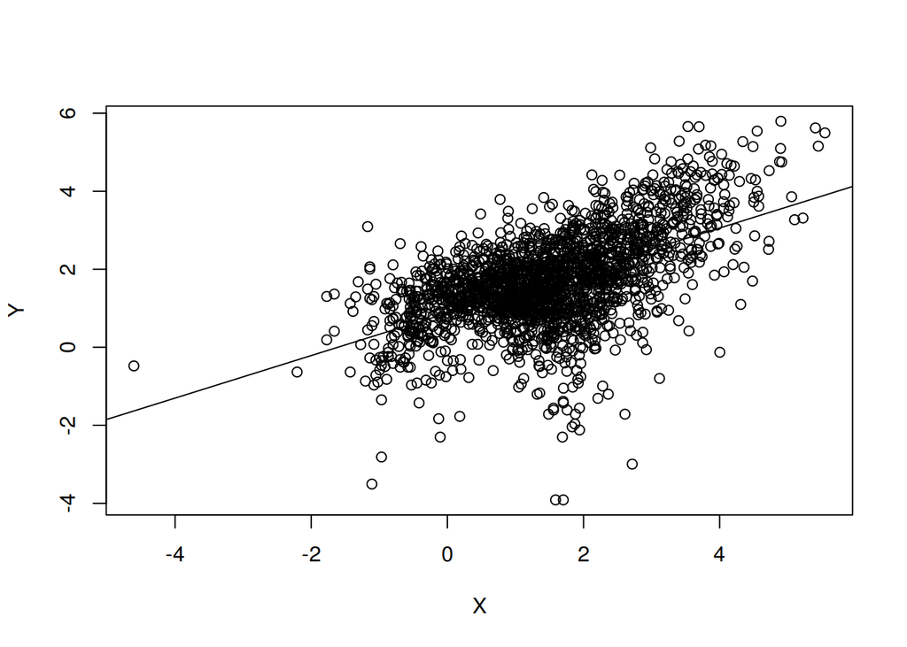

```r
## Faça o gráfico da relação entre Taxa e Vendas, e insira a linha do
## modelo com abline()
plot(Y ~ X, data = dados)
abline(mod)
```

Qual a sua conclusão sobre o modelo linear ajustado? Pode-se dizer que existe uma relação significativa entre as duas variáveis?

**Resposta**: *o modelo linear ajustado mostra que a relação entre as duas variáveis é positiva e significativamente diferente de zero, ou seja, existem evidências de que o valor de mercado de uma empresa aumenta conforme aumentam os volumes de venda.*